# Demo 8 | Global Spatial Statistics

Peter Kedron

2026-10-19

# 1. Introduction

Earlier demonstrations worked with **point patterns**, where the question was whether the *locations* of events were clustered, random, or dispersed. Much geographic data instead arrives as **areal data**: a value attached to each polygon in a set of polygons that covers the study region. A disease rate for each county, median income for each census tract, and the share of a watershed under forest are all areal data. For areal data the question changes. The polygons are fixed, so we no longer ask whether locations cluster; we ask whether the *values* do. Do counties with high rates tend to sit next to other counties with high rates?

That tendency is **spatial autocorrelation**. Positive spatial autocorrelation means nearby areas have similar values, negative spatial autocorrelation means nearby areas have dissimilar values, and its absence means the values are arranged on the map as if at random. A **global statistic** summarizes this property for the whole map with a single number, which is then compared with what we would expect if the values had been arranged at random. Global statistics tell us *whether* a map departs from spatial randomness, but not *where* the departure occurs; that is the job of the local statistics we will meet later in the course.

Every global statistic depends on a decision the analyst makes before any calculation: which areas count as “nearby.” That decision is recorded in a **spatial weights matrix**, and different, equally defensible matrices can give different answers. This demonstration calculates two global statistics, Moran’s $I$ and the Getis–Ord General $G$, for COVID-19 incidence in the counties of New England, and repeats each calculation under four spatial weights matrices to see how much that decision matters. It follows the materials presented in Rogerson (2021, ch. 5) and Rogerson and Yamada (2008, ch. 3).

**Keywords:** spatial autocorrelation, spatial weights, Moran’s I, Getis–Ord General G, areal data

## 1.1 Data

This demonstration uses a single boundary file that carries COVID-19 counts for every county in New England.

**New England counties (`NewEngland.shp`):** 65 of the 67 counties of Connecticut, Maine, Massachusetts, New Hampshire, Rhode Island, and Vermont, stored in the WGS 1984 UTM Zone 19N projection, so coordinates are in meters. Each county carries the following attributes:

- `Confirmed`: the cumulative count of confirmed COVID-19 cases.
- `Deaths`: the cumulative count of COVID-19 deaths.
- `Incident_R`: the incidence rate, confirmed cases per 100,000 residents. This is the variable analyzed throughout the demonstration.
- `Case_FR`: the case fatality rate, deaths as a percentage of confirmed cases.
- `Pop_2019`: the county’s 2019 population estimate.
- `E_Cases` and `E_Deaths`: the cases and deaths expected if every county shared the regional rate, calculated as the regional total multiplied by the county’s share of the regional population.
- `Z_Cases` and `Z_Deaths`: $z$-scores comparing the observed and expected counts.

The counts were downloaded from Esri’s COVID-19 GIS Hub (coronavirus-resources.esri.com), which redistributed the county-level case and death counts compiled by the Johns Hopkins University Center for Systems Science and Engineering from state and local health departments. They are cumulative from the start of the pandemic to the date in the `Last_Updat` field. The two island counties of Massachusetts, Dukes (Martha’s Vineyard) and Nantucket, are not in the file, most likely because their cases were reported as a single combined entry that does not match either county’s boundary. The population estimates and the expected counts were added to the file to accompany Rogerson (2021).

An incidence rate is analyzed rather than the raw count of cases because counts largely track population. A map of counts would mostly show where people live, and its spatial autocorrelation would reflect the clustering of population rather than any clustering of risk.

```r
# Load the New England county boundaries and their COVID-19 attributes
ne <- st_read("NewEngland.shp", quiet = TRUE) %>%
  mutate(rate = as.numeric(Incident_R),
         name = paste0(COUNTY, ", ", STATE))

# The variable analyzed throughout: confirmed cases per 100,000 residents
x <- ne$rate
```

The counts run to September 14, 2020, and the regional summary of the incidence rate is shown below.

| Counties | Minimum | Median | Mean | Maximum | Standard deviation |
| --- | --- | --- | --- | --- | --- |
| 65 | 47.7 | 349.8 | 652 | 2885.2 | 695.1 |

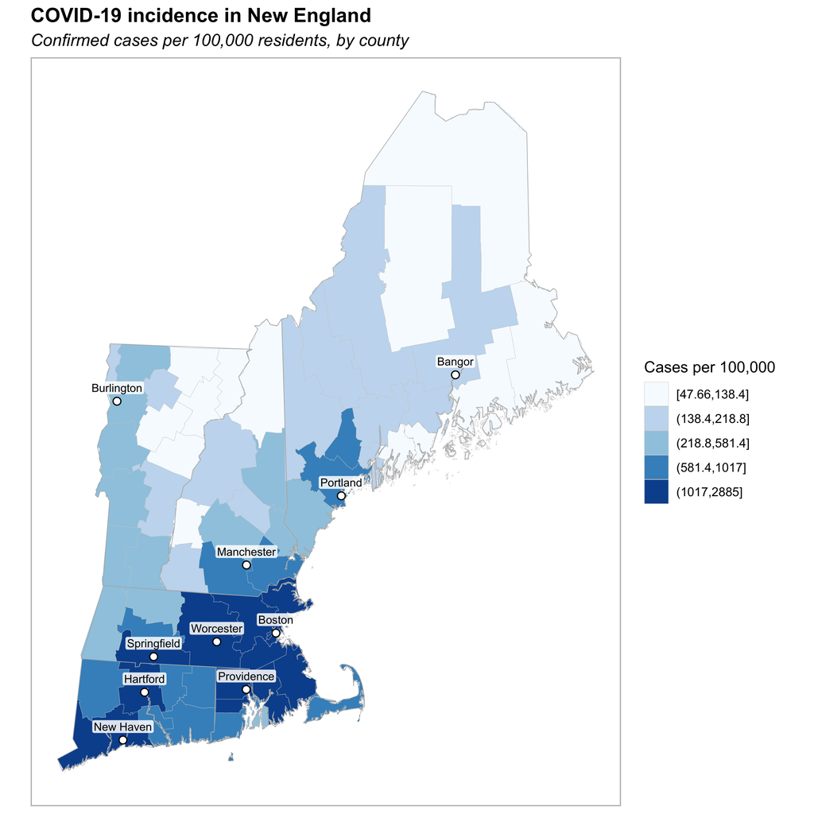

Figure 1: COVID-19 incidence by county, in quintiles, with state boundaries and major cities for reference.

Before calculating any statistic, look at the map. The highest rates are concentrated in southern New England, around Boston, Providence, and the Connecticut corridor to New York, while northern New England, especially Maine, Vermont, and northern New Hampshire, has much lower rates. If the map shows anything, it is high values next to high values and low values next to low values, which we would expect to produce a clearly positive Moran’s $I$.

# 2. Spatial Weights

A spatial weights matrix $W$ records the relationship between every pair of areas. For $n$ areas it is an $n \times n$ matrix

$$W = \begin{pmatrix}
w_{11} & w_{12} & \cdots & w_{1n} \\
w_{21} & w_{22} & \cdots & w_{2n} \\
\vdots & \vdots & \ddots & \vdots \\
w_{n1} & w_{n2} & \cdots & w_{nn}
\end{pmatrix}$$

where $w_{ij}$ describes the relationship between area $i$ and area $j$. A value of 0 means the two areas are not related, and larger values mean a stronger relationship. The diagonal is set to zero, $w_{ii} = 0$, so that no area counts as its own neighbor.

In the R package **spdep**, a weights matrix is built in two steps.

- First, a *neighbor list* (class `nb`) records which areas are related, storing for each area the index numbers of its neighbors.
- Second, `nb2listw()` converts the neighbor list to a *weights list* (class `listw`) by attaching a value to each neighbor relationship. The `style` argument of `nb2listw()` controls those values. Here every matrix uses `style = "B"`, which keeps the values exactly as given (1 for each neighbor unless we supply our own values), so that Moran’s $I$ and the General $G$ are calculated on identical matrices. Row standardization (`style = "W"`), in which each area’s weights are rescaled to sum to 1, is a common alternative for Moran’s $I$, but it is not appropriate for the General $G$.

Two families of weights are compared: two based on adjacency, and two based on distance.

```r
# Represent each county by a point for the distance-based weights and for drawing links.
# of_largest_polygon = TRUE places the point on the mainland part of counties with offshore islands.
pts <- st_centroid(st_geometry(ne), of_largest_polygon = TRUE)
coords <- st_coordinates(pts)
```

## 2.1 Adjacency Weights

Adjacency weights relate areas that share a boundary. The function `poly2nb()` builds the neighbor list directly from the polygons.

- **Queen contiguity** (`queen = TRUE`) treats two counties as neighbors if their boundaries touch at all, even at a single point:

$$w_{ij} = \begin{cases} 1, & \text{bnd}(i) \cap \text{bnd}(j) \neq \emptyset \\ 0, & \text{otherwise} \end{cases}$$

- **Rook contiguity** (`queen = FALSE`) requires the two counties to share a boundary segment of positive length $l_{ij}$, so counties that meet only at a corner are not neighbors:

$$w_{ij} = \begin{cases} 1, & l_{ij} > 0 \\ 0, & l_{ij} = 0 \end{cases}$$

```r
# Queen contiguity: boundaries touch at any point
nb_queen <- poly2nb(ne, queen = TRUE)
lw_queen <- nb2listw(nb_queen, style = "B")

# Rook contiguity: boundaries share a segment of positive length
nb_rook <- poly2nb(ne, queen = FALSE)
lw_rook <- nb2listw(nb_rook, style = "B")
```

## 2.2 Distance Weights

Distance weights relate areas according to the distance $d_{ij}$ between their representative points, here the county centroids. They do not depend on shared boundaries, so they can relate areas that touch nothing, and they let the analyst control how far a relationship reaches.

- **k-nearest-neighbor weights** give a weight of 1 to the $k$ counties whose centroids are closest to county $i$, where $N_k(i)$ is the set of those $k$ counties. Here $k = 4$. Because $j$ can be among $i$’s nearest neighbors without $i$ being among $j$’s, this matrix is generally not symmetric.

$$w_{ij} = \begin{cases} 1, & j \in N_k(i) \\ 0, & \text{otherwise} \end{cases}$$

- **Inverse-distance weights** let the strength of the relationship decline with distance. Every pair of counties within a threshold distance $d$ (the bandwidth) is related, with a weight equal to the inverse of the distance between them in kilometers. Pairs farther apart than $d$ get a weight of 0.

$$w_{ij} = \begin{cases} d_{ij}^{-1}, & d_{ij} \le d \\ 0, & d_{ij} > d \end{cases}$$

The bandwidth is set to the smallest distance at which every county has at least one neighbor: the largest of the counties’ nearest-neighbor distances.

```r
# k-nearest-neighbor weights, k = 4
nb_knn <- knn2nb(knearneigh(coords, k = 4))
lw_knn <- nb2listw(nb_knn, style = "B")

# Bandwidth: the largest nearest-neighbor distance, so no county is left without a neighbor
nn_dist <- unlist(nbdists(knn2nb(knearneigh(coords, k = 1)), coords))
band <- max(nn_dist)

# Inverse-distance weights within the bandwidth, with distances in kilometers
nb_dist <- dnearneigh(coords, d1 = 0, d2 = band)
inv_d <- lapply(nbdists(nb_dist, coords), function(d) 1 / (d / 1000))
lw_dist <- nb2listw(nb_dist, glist = inv_d, style = "B")
```

The bandwidth is 105.8 km.

## 2.3 Comparing the Weights

The figure below draws each neighbor relationship as a line between county centroids.

[figure not shown]

Figure 2: Neighbor relationships under the four spatial weights matrices.

Weights

Links

Mean neighbors

Fewest neighbors

Most neighbors

Counties with no neighbors

1. Queen contiguity

298

4.58

1

10

0

2. Rook contiguity

298

4.58

1

10

0

3. k-nearest neighbors (k = 4)

260

4.00

4

4

0

4. Inverse distance

738

11.35

1

21

0

The four matrices describe noticeably different networks. Queen and rook contiguity produce exactly the same neighbors here, because no two New England counties meet only at a single point; the stricter rook rule has nothing to remove. On a map of square grid cells the two rules would differ for every cell. Because the island counties are missing, every county in the file has at least one contiguity neighbor. Contiguity is uneven, though: counties range from 1 to 10 neighbors. The k-nearest-neighbor matrix removes that unevenness by giving every county exactly four neighbors, which also makes it the sparsest of the four matrices. The inverse-distance matrix is the densest, averaging 11.4 neighbors per county, because the bandwidth needed to reach the most isolated centroid also connects each of the small southern counties to many others; its weights, however, shrink as distance grows.

**Questions to consider**

Every matrix in this section is built from geometry alone: shared boundaries, or straight-line distance between centroids. But a virus does not travel in straight lines between county centroids; it travels with people.

1. Suppose $w_{ij}$ were based on **travel time** by road rather than straight-line distance. Which pairs of New England counties would become more closely related, and which less? Think about the interstate corridors around Boston and Hartford, and the mountains of northern New Hampshire and western Maine.
2. Suppose instead $w_{ij}$ were the number of people who **commute** from county $i$ to county $j$. How would this matrix differ from the four above, and would you expect it to be symmetric?
3. Diseases often spread down the **urban hierarchy**, jumping first between large, well-connected cities (Boston, Providence, Hartford, Portland) and only later reaching the smaller towns and rural counties around them. How could you build a weights matrix that links counties by the size of their largest city rather than by how close they are, and would you expect Moran’s $I$ to be larger or smaller under that matrix?

# 3. Moran’s I

Moran’s $I$ measures whether areas tend to have values similar to those of their neighbors.

$$I = \frac{n\sum_{i=1}^{n}\sum_{j=1}^{n} w_{ij}\,(x_i - \bar{x})(x_j - \bar{x})}{\sum_{i=1}^{n}\sum_{j=1}^{n} w_{ij}\sum_{i=1}^{n} (x_i - \bar{x})^2}$$

where $x_i$ is the incidence rate in county $i$, $\bar{x}$ is the mean rate, and $w_{ij}$ is the weight between counties $i$ and $j$. For every pair of neighbors, the numerator multiplies their deviations from the mean, so pairs that are both above or both below the mean add to $I$ and pairs on opposite sides subtract from it. Values near +1 indicate strong positive spatial autocorrelation, values near 0 indicate spatial randomness, and negative values indicate negative spatial autocorrelation.

Under the null hypothesis of no spatial autocorrelation, the expected value is slightly negative, $E[I] = -1/(n-1)$, and the observed $I$ is compared with it using a $z$-score

$$z_I = \frac{I - E[I]}{\sqrt{Var[I]}}$$

The spdep function `moran.test()` calculates $I$, $E[I]$, $Var[I]$, and the $z$-score, with a $p$-value from the normal distribution. Its argument `randomisation = TRUE` (the default) computes $Var[I]$ under the assumption that every rearrangement of the observed values over the counties is equally likely; `randomisation = FALSE` uses the normality assumption instead. The function `moran.mc()` tests the same null by simulation, without assuming a normal distribution: it randomly reassigns the observed rates to the counties `nsim` times, recalculates $I$ each time, and reports the share of the simulated values at least as large as the observed one.

```r
# Run the analytic and permutation tests of Moran's I for one weights matrix
lw_list <- list("Queen" = lw_queen, "Rook" = lw_rook,
                "k-nearest (k = 4)" = lw_knn, "Inverse distance" = lw_dist)

moran_row <- function(lw) {
  mt <- moran.test(x, lw, randomisation = TRUE)
  set.seed(1722)
  mc <- moran.mc(x, lw, nsim = 999, alternative = "greater")
  tibble(I = unname(mt$estimate["Moran I statistic"]),
         `E[I]` = unname(mt$estimate["Expectation"]),
         `Var[I]` = unname(mt$estimate["Variance"]),
         z = unname(mt$statistic),
         p = mt$p.value,
         `Permutation p` = mc$p.value)
}

moran_table <- bind_rows(lapply(lw_list, moran_row), .id = "Weights")

moran_table %>%
  mutate(p = p_fmt(p), `Permutation p` = formatC(`Permutation p`, format = "f", digits = 3)) %>%
  kable(digits = 4, align = "lrrrrrr") %>%
  kable_styling(full_width = T)
```

| Weights | I | E[I] | Var[I] | z | p | Permutation p |
| --- | --- | --- | --- | --- | --- | --- |
| Queen | 0.6474 | -0.0156 | 0.0059 | 8.5961 | < 0.001 | 0.001 |
| Rook | 0.6474 | -0.0156 | 0.0059 | 8.5961 | < 0.001 | 0.001 |
| k-nearest (k = 4) | 0.6801 | -0.0156 | 0.0062 | 8.8088 | < 0.001 | 0.001 |
| Inverse distance | 0.6180 | -0.0156 | 0.0026 | 12.5163 | < 0.001 | 0.001 |

**Interpretation:** Under every weights matrix, $I$ is between 0.62 and 0.68, far above its expected value of -0.0156, and both the analytic and the permutation $p$-values are well below 0.05. With 999 permutations, the smallest possible permutation $p$-value is 1/1000 = 0.001, which is what every matrix returns. We reject the null hypothesis that COVID-19 incidence is arranged at random across the counties: counties with high rates tend to neighbor counties with high rates, and counties with low rates tend to neighbor counties with low rates.

The permutation test can be drawn. Each panel below shows the 999 values of $I$ from randomly rearranged maps, with the observed value marked in red.

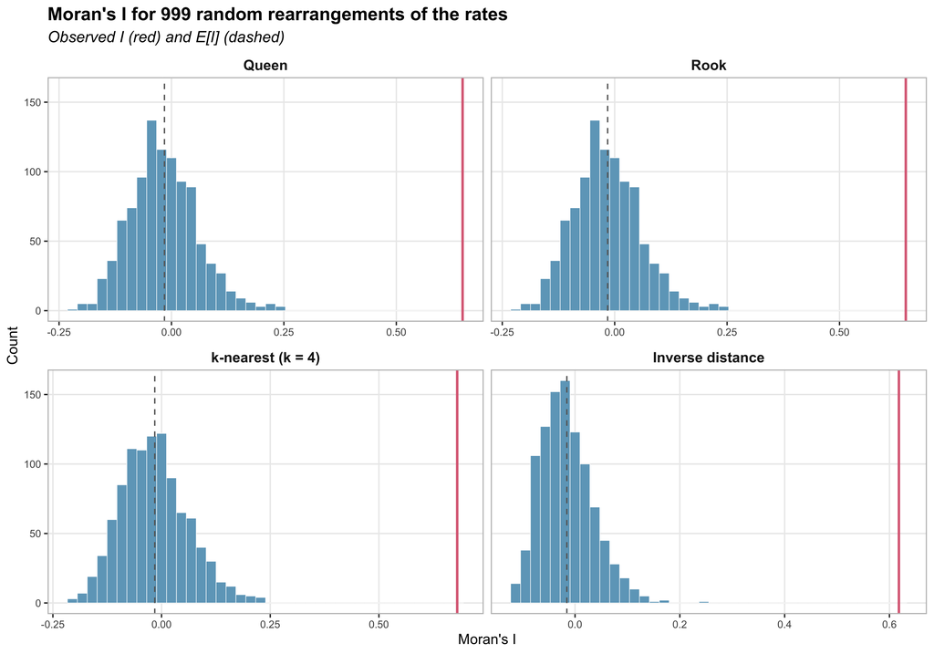

Figure 3: Permutation distributions of Moran’s $I$ under each weights matrix.

**Interpretation:** In every panel the observed $I$ lies far to the right of all 999 simulated values, so none of the random rearrangements produced as much clustering of similar values as the real map.

A **Moran scatterplot** shows where $I$ comes from. It plots each county’s standardized rate against the average standardized rate of its neighbors (the *spatial lag*), here using queen contiguity with row-standardized weights so that the lag is an average. Counties in the upper-right quadrant are high-rate counties surrounded by high-rate neighbors, and counties in the lower-left are low-rate counties surrounded by low-rate neighbors; both add to $I$. The slope of the fitted line equals Moran’s $I$ calculated with row-standardized weights.

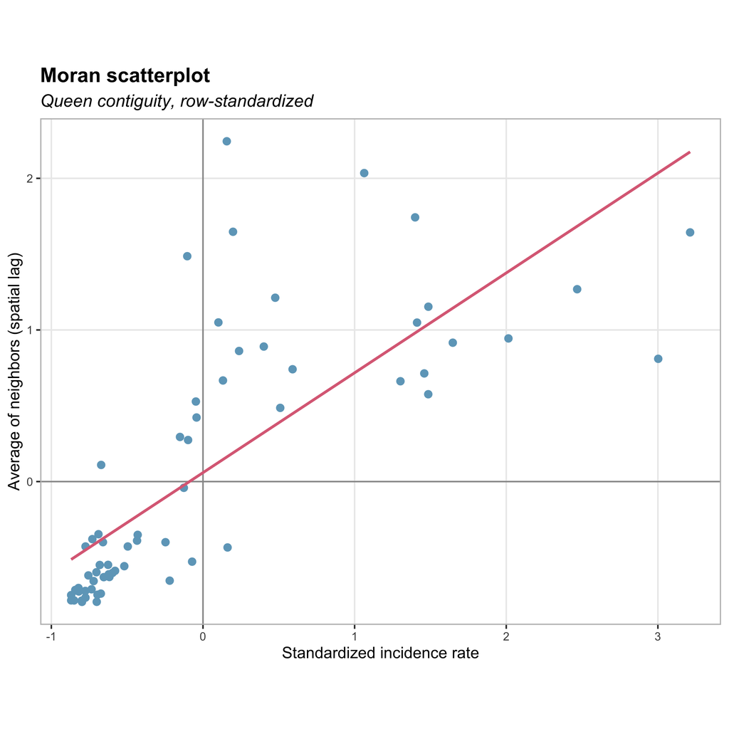

Figure 4: Moran scatterplot of COVID-19 incidence.

# 4. Getis–Ord General G

The General $G$ statistic asks a different question. Rather than whether neighbors are *similar*, it asks whether *high* values are concentrated near one another.

$$G(d) = \frac{\sum_{i=1}^{n}\sum_{j=1}^{n} w_{ij}(d)\, x_i x_j}{\sum_{i=1}^{n}\sum_{j=1}^{n} x_i x_j}, \quad i \neq j$$

The numerator and denominator differ only in the weights. The denominator adds the products $x_i x_j$ for every pair of counties, and the numerator adds them only for pairs that are related in $W$. $G$ is therefore the share of all value products that falls on neighboring pairs. Because the products of two high values are large, $G$ grows when high values sit next to each other. The statistic requires positive values, which incidence rates are.

Under the null hypothesis of no spatial clustering, the expected value depends only on the weights,

$$E[G(d)] = \frac{W}{n(n-1)}, \qquad W = \sum_{i=1}^{n}\sum_{j=1}^{n} w_{ij}(d), \quad i \neq j$$

and the observed $G$ is compared with it using

$$z_G = \frac{G(d) - E[G(d)]}{\sqrt{Var[G(d)]}}$$

A significant positive $z_G$ means high values are clustered; a significant negative $z_G$ means low values are clustered. The spdep function `globalG.test()` returns $G$, $E[G]$, $Var[G]$, and $z_G$.

```r
# Run the General G test for one weights matrix
g_row <- function(lw) {
  gt <- globalG.test(x, lw, alternative = "two.sided")
  tibble(G = unname(gt$estimate["Global G statistic"]),
         `E[G]` = unname(gt$estimate["Expectation"]),
         `Var[G]` = unname(gt$estimate["Variance"]),
         z = unname(gt$statistic),
         p = gt$p.value)
}

g_table <- bind_rows(lapply(lw_list, g_row), .id = "Weights")

# G, E[G], and Var[G] are small numbers, so they are shown with significant digits
g_table %>%
  mutate(across(c(G, `E[G]`), ~ formatC(.x, format = "g", digits = 4)),
         `Var[G]` = formatC(`Var[G]`, format = "e", digits = 2),
         z = round(z, 2),
         p = p_fmt(p)) %>%
  kable(align = "lrrrrr") %>%
  kable_styling(full_width = T)
```

| Weights | G | E[G] | Var[G] | z | p |
| --- | --- | --- | --- | --- | --- |
| Queen | 0.1267 | 0.07163 | 8.56e-05 | 5.95 | < 0.001 |
| Rook | 0.1267 | 0.07163 | 8.56e-05 | 5.95 | < 0.001 |
| k-nearest (k = 4) | 0.1134 | 0.0625 | 4.17e-05 | 7.88 | < 0.001 |
| Inverse distance | 0.006432 | 0.002958 | 1.42e-07 | 9.23 | < 0.001 |

**Interpretation:** The values of $G$ look tiny, but they must be read against $E[G]$, which is also small because only a small share of all county pairs are neighbors. In every row $G$ is between 1.8 and 2.2 times larger than $E[G]$, and the large positive $z$-scores indicate that the counties with high incidence rates are clustered together.

# 5. Comparison and Interpretation

The $z$-scores put the two statistics on a common scale.

| Weights | Moran’s I z | General G z | Moran’s I p | General G p |
| --- | --- | --- | --- | --- |
| Queen | 8.60 | 5.95 | < 0.001 | < 0.001 |
| Rook | 8.60 | 5.95 | < 0.001 | < 0.001 |
| k-nearest (k = 4) | 8.81 | 7.88 | < 0.001 | < 0.001 |
| Inverse distance | 12.52 | 9.23 | < 0.001 | < 0.001 |

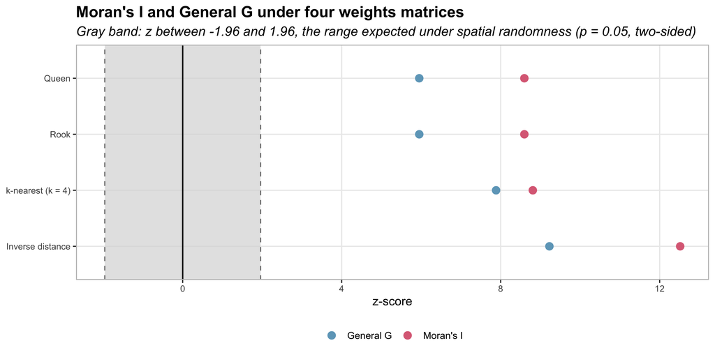

Figure 5: $z$-scores for both statistics under each weights matrix.

**Interpretation:** Both statistics reject spatial randomness under all four weights matrices, so the conclusion that COVID-19 incidence is spatially clustered in New England does not depend on how neighbors are defined. The *strength* of the evidence does change with the weights. The inverse-distance matrix, which relates the most pairs of counties, gives the largest $z$-scores for both statistics (12.5 for $I$ and 9.2 for $G$). The k-nearest-neighbor matrix gives larger $z$-scores than contiguity even though it uses fewer links, so the number of links is not the whole story: *which* pairs of counties are related matters too. Queen and rook give identical results because, as Section 2.3 showed, they are the same matrix for these counties. The two statistics answer different questions. Moran’s $I$ says that similar rates sit together, which includes both the high-rate south and the low-rate north. The General $G$ says that the high rates in particular are concentrated, which points to southern New England as the source of the clustering. Neither statistic says *where* the clusters are; mapping them is the work of the local statistics introduced later in the course.

### Declaration of Generative AI and AI-Assisted Technologies

The author used Anthropic’s Claude (Opus 5.5) when developing this demonstration. A connection to RStudio through the ClaudeR package was used to draft and debug the R code. The author subsequently reviewed and edited all of that output and takes full responsibility for the content.